# Maximizando suas possibilidades com R e python

Bruno Lucian - Rede Globo

22 Maio 2019

`#python #rstats` `#rpy2 #reticulate` `@projectjupyter` `@rstudio`  
`@brunolucian`

[figure not shown]

[figure not shown]

Rankings das linguagem de programação (Redmonk, Q1 2018).

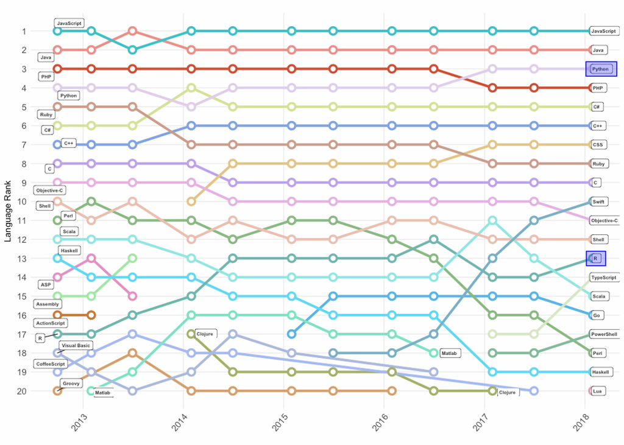

Evolução ao longo do tempo. (Redmonk, Q1 2018).

#### R

- Primeira release em 1995

#### Pontos Fortes

- Muitas opçoes de pacotes no [CRAN](https://cran.r-project.org/)
- Muitos conjuntos de dados disponíveis
- Grande opções de distribuições estatisticas
- Excelente documentação

#### Pontos Fracos

- pode ser lento e consumir muita memória
- curva de aprendizado pode ser desafiadora.

### Python

- Primeira release em 1991
- primeira release do, scikit-learn em 2007 e do pandas em 2008.

#### Pontos fortes

- Explicitamente orientada a objetos
- Incentiva código estruturado
- De uso geral
- Simples para colocar algoritmos em produção.

#### Pontos fracos

- Não é nativa para os problemas de Data Science
- Dependencia de modulos pode ser um desafio.

Como podemos  
aproveitar  
o  
melhor  
dos  
dois  
mundos?

Não pensamos duas vezes antes de misturar um pouco de SQL com a linguagem que estamos usando.

```r
# R
#
dbGetQuery(db, "SELECT * FROM customer;")
```

```r
# Python
#
db.execute("SELECT * FROM customer;")
```

[figure not shown]

[figure not shown]

## Opções para uso do Python com R

- [PypeR](http://bioinfo.ihb.ac.cn/softwares/PypeR/)
  - release 1.1.2 (2014)
- [pyRserve](https://pypi.org/project/pyRserve/)
  - uses [Rserve](http://www.rforge.net/Rserve/)
  - release 0.9.1 (2017)
- [rpy2](https://rpy2.bitbucket.io/)
  - roda o R incorporado em um processo Python
  - release 2.9.4 (2018)

[figure not shown]

https://rpy2.bitbucket.io/

- Instalação via `pip`.

```bash
pip install rpy2
```

## Opções para uso do R com Python

- [rJython](https://r-forge.r-project.org/projects/rjython/)
  - release 0.0-4 (2012)
- [rPython](http://rpython.r-forge.r-project.org/)
  - release 0.0-6 (2015)
- SnakeCharmR
  - release 1.0.7 (2017)
- [PythonInR](https://bitbucket.org/Floooo/pythoninr/)
  - release 0.1-4 (2018)
- reticulate
  - roda o Python incorporado em um processo R
  - release 1.8 (2018)

https://github.com/rstudio/reticulate

- Instalação pelo CRAN ou GitHub.

```r
# - CRAN
install.packages("reticulate")
# - GitHub
devtools::install_github("rstudio/reticulate")
```

[figure not shown]

### rpy2

- Roda código R
- Jupyter magic: `%R`(inline) e `%%R`(bloco)
- `-i` e `-o` para bloco
- `pandas2ri` conversão

### reticulate

- roda código python
- ambiente virtuais
- `import()` módulos
- `repl_python()`
- `py$` e `r.` para navegar entre os objetos

Claramente  
ambas  
linguagem são  
importantes.

Um Cientista de dados deveria pelo menos  
compreender  
as  
duas.

Nós podemos  
dividir nosso amor entre ambas  
linguagens!

Devemos trabalhar  
juntos  
e  
Shallow Now.

### Agradecimentos

- Comissão do IV SER
- Rede Globo
- Andrew B. Collier